ChimeraMapR · v0.7.0

# Using the ChimeraMapR Shiny app

A click-through walkthrough of the interactive app — upload three files, run the analysis pipeline stage by stage, and read the peak, LOH, fusion, and recombination-event tabs it produces, using real yeast chromosome I data the whole way through.

R ≥ 4.1 shiny::runApp("app.R") S. cerevisiae chrI test data

## What you need first

- R ≥ 4.1, with `shiny`, `data.table`, `ggplot2`, `pracma`, `Matrix`, `Rcpp`, and `igraph` installed.
- A C++ toolchain (Xcode CLT on macOS) — `chimera_functions.R` compiles an Rcpp HMM the first time it's sourced.
- Three input files: a read-level SNP call CSV, a SNP definition file (CSV or VCF), and a `.fai` chromosome size index. See *Input files* in the README for the exact schema — this tutorial uses the ready-made copies in `test_data/`.

**No install step needed to try this.** If you've cloned the ChimeraMapR repo, `test_data/chrI.csv.gz`, `test_data/chrI_SNPs.vcf.gz`, and `test_data/ref_genome.fasta.fai` are already there — every screen below was produced by uploading those three files as-is.

01

## Launch the app

From the repo root, start the app with `shiny::runApp()` and let it open your default browser:

terminal

```
$ R -e "shiny::runApp('app.R', launch.browser = TRUE)"

Loading required package: shiny
Listening on http://127.0.0.1:XXXX
```

On macOS/Linux, symlink `chimera.sh` onto your `PATH` (e.g. as `/usr/local/bin/chimera`) to launch the same thing with a bare `chimera` command from any directory. The sidebar on the left holds file inputs and analysis parameters; the tab strip on the right is where every result lands.

02

## Upload the three input files

Under **Data Files**, use the three **Browse…** buttons to supply the read-level SNP calls, the SNP definition file, and the chromosome-size index. Each shows an `Upload complete` bar once accepted — the SNP file accepts CSV, VCF, or gzipped VCF, auto-detected from the extension. Give the run a **Sample Name** (it's used in exported filenames and plot titles); REF/ALT strain names are optional and only affect legend labels on the LOH bands.

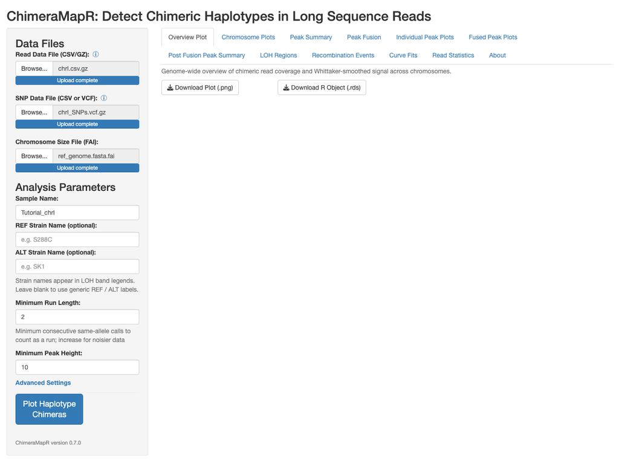

All three files accepted — each shows a solid "Upload complete" bar. Sample name set to `Tutorial_chrI`; REF/ALT strain names left blank, so the app falls back to generic REF/ALT labels.

**200 MB upload ceiling.** The app raises Shiny's default request-size limit, but very large read CSVs should still be gzipped first — the read-data input accepts `.gz` directly.

03

## Set analysis parameters

**Minimum Run Length** and **Minimum Peak Height** sit directly in the sidebar since they're the two knobs worth tuning on a first pass. Everything else lives behind the collapsed **Advanced Settings** disclosure — quality cutoffs, the Whittaker smoothing penalty, and the fusion/chain-analysis thresholds described below.

[output not shown]

04

## Run the analysis

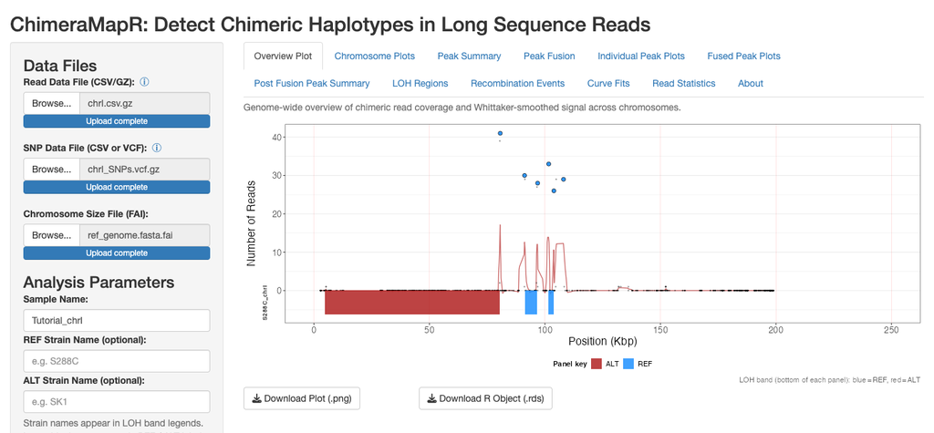

Overview Plot tab. Six peaks cluster between ~80 kb and ~108 kb; the wide red band at the bottom of the panel is the ALT-fixed LOH region, blue bands mark REF-fixed tracts. The red curve is the Whittaker-smoothed fit that peak detection runs against.

05

## Read the Peak Summary and Individual Peak Plots tabs

**Peak Summary** lists every detected peak with its position, boundaries, height, supporting read count, and haplotype classification (`binary`, `compound_binary`, `gene_conversion`, `internal_crossover`, or `undefined`) — the same run-pattern label the CLI's `--peak-list` mode writes out.

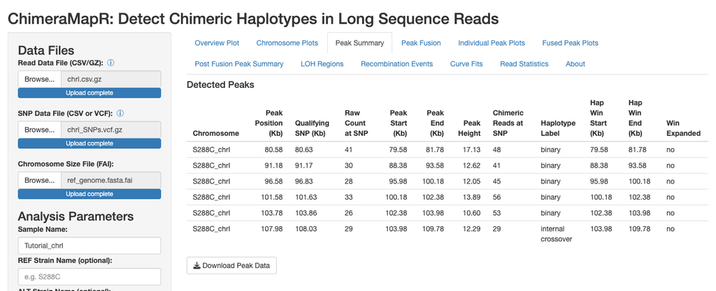

Detected Peaks table. Five clean `binary` switches plus one `internal_crossover` at 107.98 Kb — a peak whose underlying reads switch back rather than making one sustained transition, which peak fusion and the event caller try to resolve into an actual call.

**Individual Peak Plots** renders one panel per peak, per chromosome tab: every chimeric read spanning that peak, coloured REF (blue) vs ALT (red), with a haplotype-region bar underneath showing the called classification.

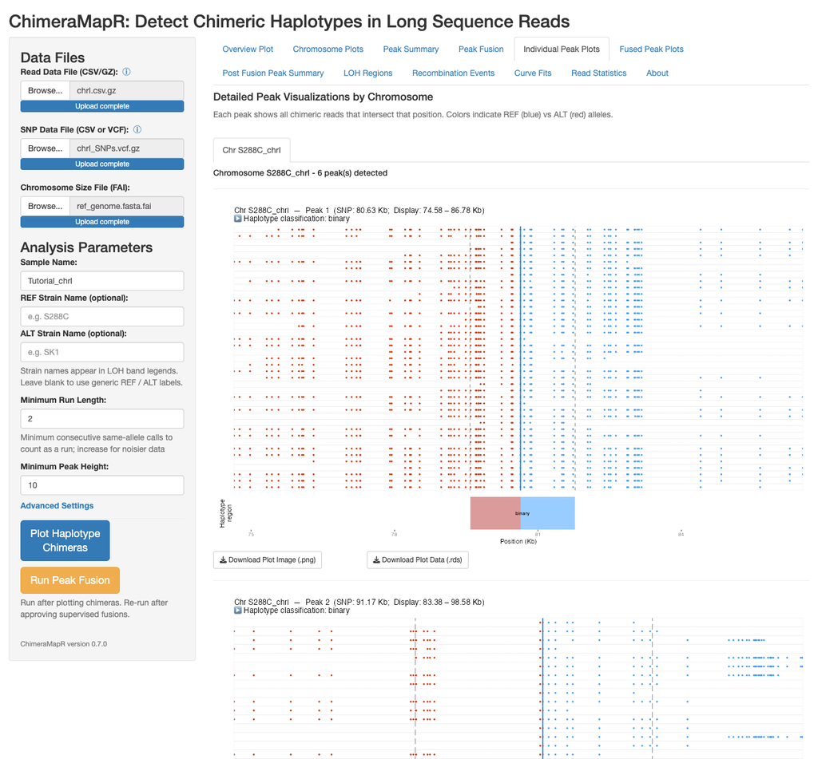

06

## Check LOH Regions

The **LOH Regions** tab shows what the beta-binomial EM + Viterbi HMM called directly from per-position allele balance — independent of peak detection. Each row is a REF-fixed or ALT-fixed tract with its mean allele balance and standard deviation, a quick sanity check on how clean the underlying calls are.

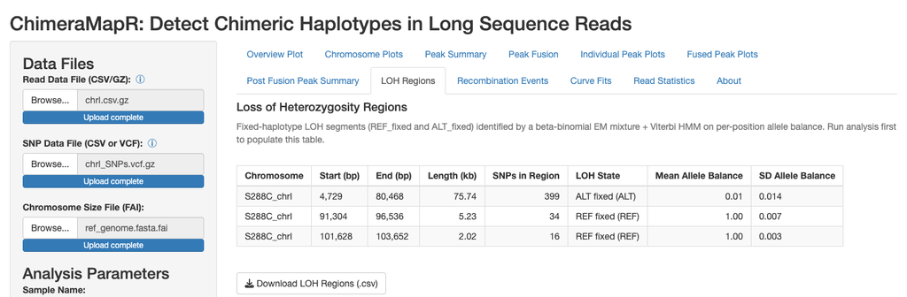

Three LOH segments on chrI: a 75.7 kb ALT-fixed tract (mean allele balance 0.01 — essentially pure ALT) and two short REF-fixed tracts with allele balance pinned at 1.00. These three tracts are what the chain analysis in step 07 combines with the fused peaks.

07

## Call recombination events

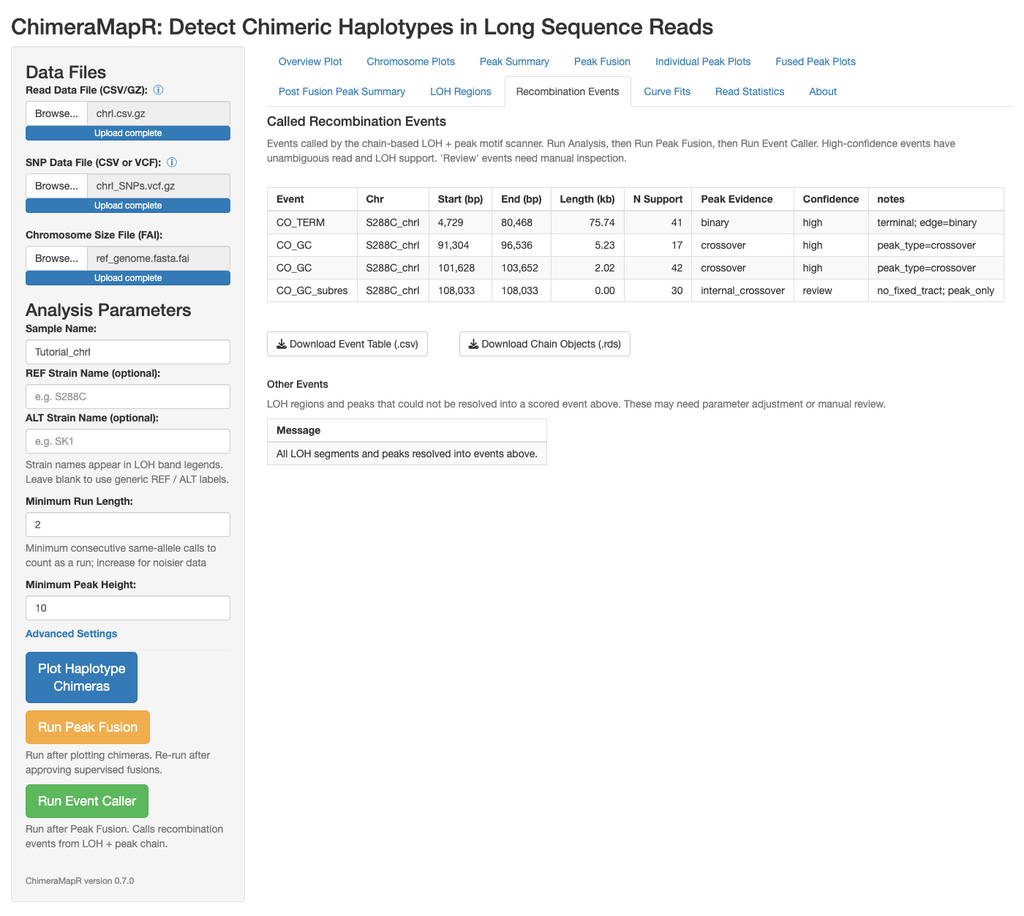

Anything the chain scanner can't fold into a scored event — an LOH tract or peak left over after matching — shows up in the **Other Events** table beneath, rather than silently disappearing. On this run, everything resolved cleanly and that table is empty.

08

## Review peak fusions (optional)

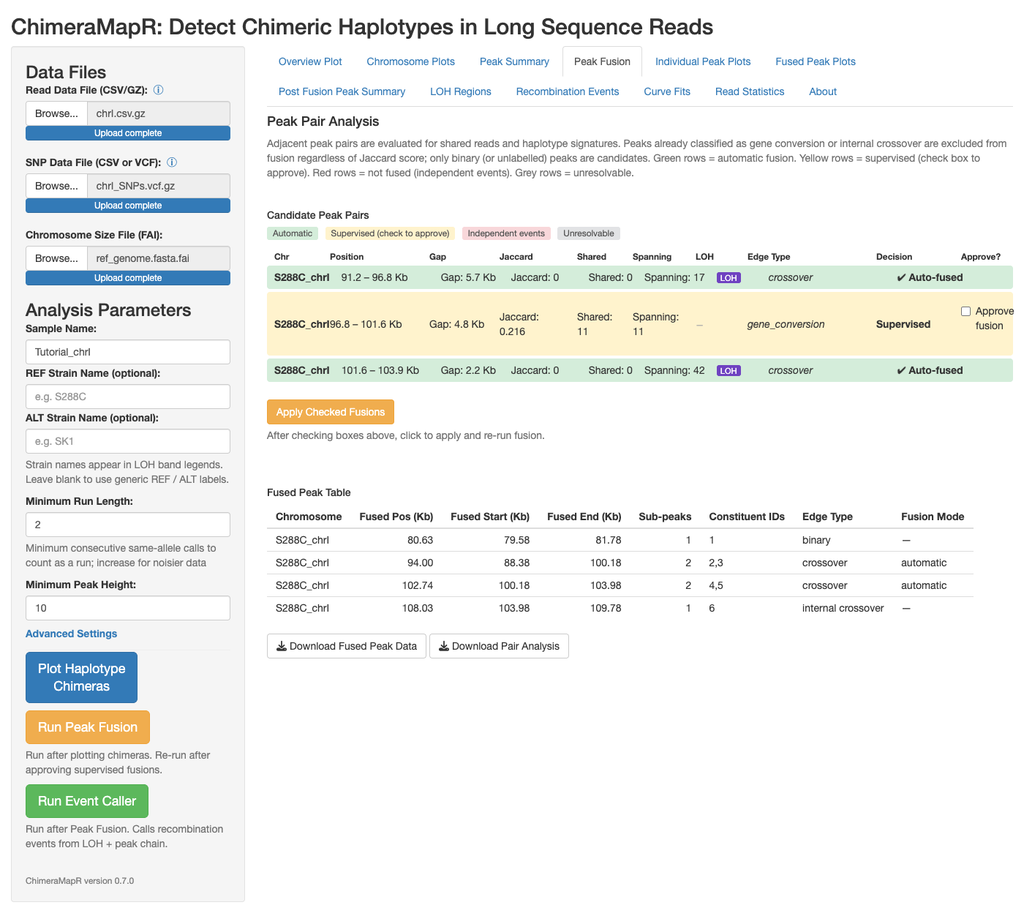

Peak Pair Analysis: two pairs auto-fuse on a `crossover` signature (green), one is flagged `gene_conversion` for supervised review (yellow) pending manual approval. The Fused Peak Table below collapses six original peaks into four groups.

09

## Export your results

Every tab has its own download button next to its table or plot, so you only need to fetch what you actually inspected:

`Download Plot (.png)` / `(.rds)`Overview Plot tab — genome-wide figure, or the raw ggplot object to re-style later

`Download Peak Data`Peak Summary tab — every detected peak with haplotype label

`Download Fused Peak Data` / `Download Pair Analysis`Peak Fusion tab — fused groups and the underlying Jaccard scoring

`Download LOH Regions (.csv)`LOH Regions tab — REF/ALT-fixed tract boundaries and allele balance

`Download Event Table (.csv)` / `Download Chain Objects (.rds)`Recombination Events tab — final calls, or the full intermediate chain objects

`Download Chimeric Read IDs`Read Statistics tab — one read ID per line, for `samtools view -N` to pull a BAM of just the chimeric reads

**Same pipeline, no UI.** Once you know which parameters work for your data, `chimera_cli.R` runs the identical analysis from the terminal for batch processing — see the companion command-line tutorial.